# Visa Exploration - Part 2

This document contains visualizations for part 2 of the STAT 331 final project.

## Group Members

- Sarthak Khillon
- Jose Mendosa
- Christina Walden

## Setup

```r
library(tidyverse)
```

```r
library(readr)
library(stringr)
library(leaflet)
library(ggplot2)
```

The data is slightly ordered–most early observations are from 2016, with some earlier years at the back of the file. We will first read in the entire file and then randomly sample 10K observations.

```r
raw.input <- read_csv("~/Desktop/DataScienceCourses/stat331/ShinyVisaExploration/h1b_kaggle.csv")
h1b.apps <- raw.input %>%
    na.omit() %>%
    sample_n(10000)

str(h1b.apps)
```

```
## Classes 'tbl_df', 'tbl' and 'data.frame':    10000 obs. of  11 variables:
##  $ X1                : int  2945622 1003548 154610 247668 1741022 1406228 1988336 1450084 1382955 2609335 ...
##  $ CASE_STATUS       : chr  "CERTIFIED" "CERTIFIED" "CERTIFIED" "CERTIFIED" ...
##  $ EMPLOYER_NAME     : chr  "UST GLOBAL INC." "BALLY GAMING, INC." "GSR TECHNOLOGIES INC." "GSS INFOTECH CT, INC." ...
##  $ SOC_NAME          : chr  "Computer Systems Analysts" "SOFTWARE DEVELOPERS, APPLICATIONS" "COMPUTER SYSTEMS ANALYSTS" "COMPUTER PROGRAMMERS" ...
##  $ JOB_TITLE         : chr  "SYSTEMS ANALYST" "ASSOCIATE SOFTWARE ENGINEER" "BUSINESS SYSTEM ANALYST" "PROGRAMMER ANALYST" ...
##  $ FULL_TIME_POSITION: chr  "Y" "Y" "N" "N" ...
##  $ PREVAILING_WAGE   : num  55266 59738 58219 59010 47674 ...
##  $ YEAR              : int  2011 2015 2016 2016 2014 2014 2013 2014 2014 2012 ...
##  $ WORKSITE          : chr  "MASON, OHIO" "LAS VEGAS, NEVADA" "IRVINE, CALIFORNIA" "GLASTONBURY, CONNECTICUT" ...
##  $ lon               : num  -84.3 -115.1 -117.8 -72.5 -76.9 ...
##  $ lat               : num  39.4 36.2 33.7 41.7 39 ...
```

## Geographic Exploration

The code below generates a leaflet plot with frequency of applications. In an interactive setting, this map could include filters to view by:

- Year
- Application status
- Employer name
- SOC name
- Job Title
- Full Time/part time
- Wage

Below is the data without any filters:

```r
leaflet(h1b.apps) %>%
    addTiles() %>%
    addMarkers(~lon, ~lat, clusterOptions = markerClusterOptions())
```

[interactive chart not shown]

Below is an example of the same map with the following filters:

```r
sample.map.filtered <- h1b.apps %>%
    filter(CASE_STATUS == "CERTIFIED" &
               FULL_TIME_POSITION == "Y" &
               (YEAR == 2011 | YEAR == 2013 | YEAR == 2016) &
               PREVAILING_WAGE > 100000 &
               grepl("executive|physicists", SOC_NAME, ignore.case = TRUE))

leaflet(sample.map.filtered) %>%
    addTiles() %>%
    addMarkers(~lon, ~lat, clusterOptions = markerClusterOptions())
```

[interactive chart not shown]

## Wages

An interesting metric is how wages for the same position have changed over time. Below we find the most common SOC in our sample and plot the change in its average wage over time.

```r
most.common.soc <- tail(names(sort(table(h1b.apps$SOC_NAME))), 1)
most.common.soc
```

```
## [1] "Computer Systems Analysts"
```

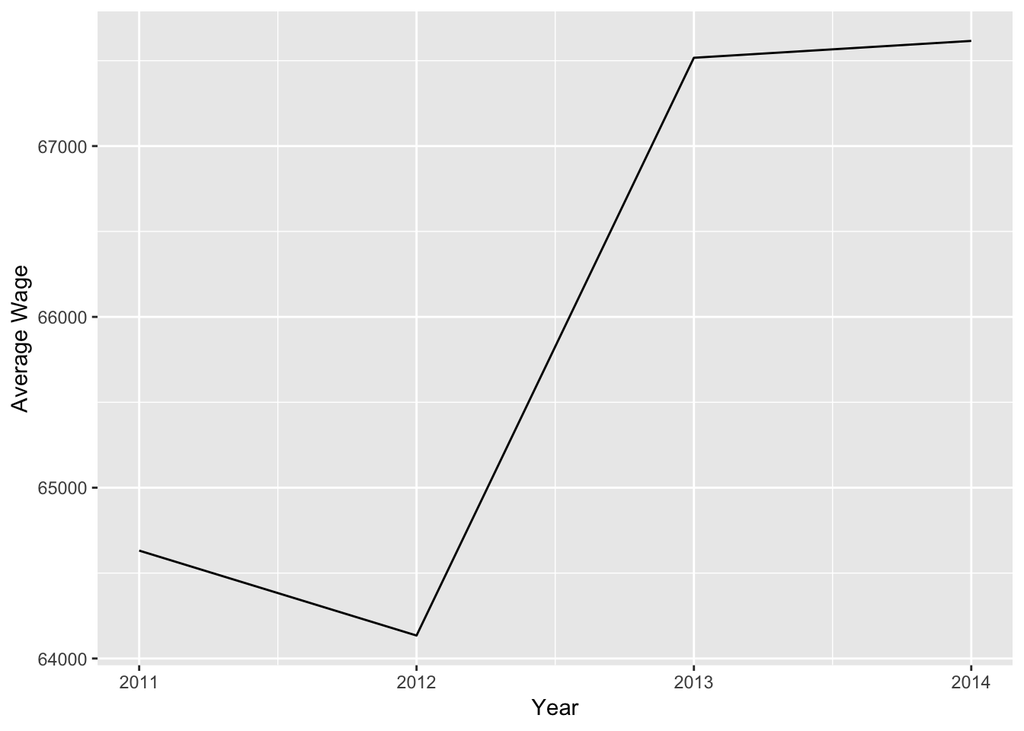

```r
h1b.apps %>%
    filter(SOC_NAME == most.common.soc) %>%
    group_by(YEAR) %>%
    summarize(av.wage.by.year = mean(PREVAILING_WAGE)) %>%
    ggplot(aes(x = YEAR, y = av.wage.by.year)) +
    geom_line() +
    xlab("Year") +
    ylab("Average Wage")
```

## Application Status

Below is a pie chart where the user may filter status by years 2011 and 2015.

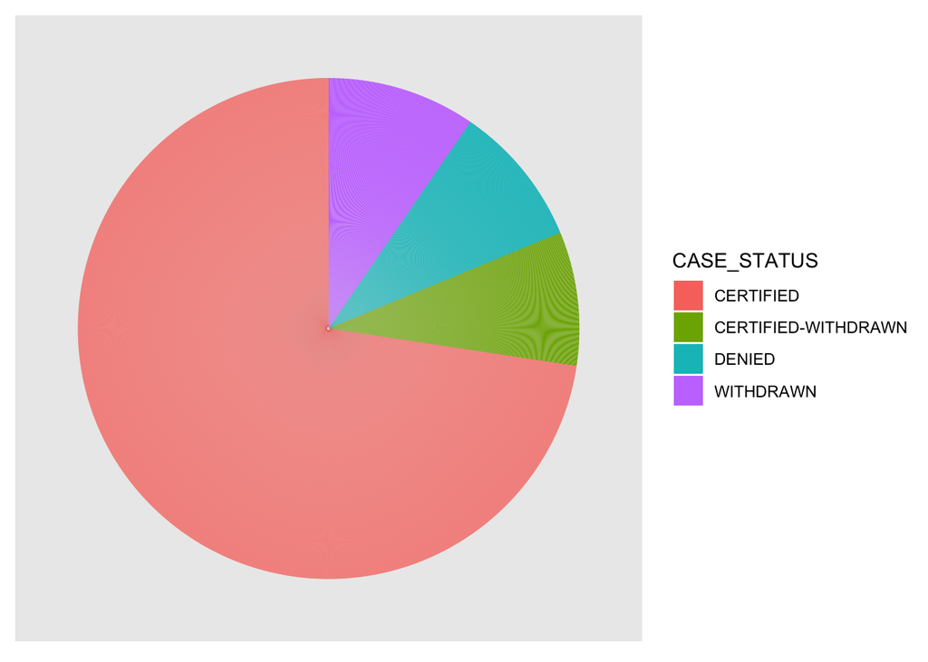

```r
h1b.apps %>%
    filter(YEAR == 2011 | YEAR == 2015) %>%
    ggplot(aes(x = "", y = CASE_STATUS, fill = CASE_STATUS)) +
    geom_bar(width = 1, stat = "identity") +
    coord_polar("y", start = 0) +
    xlab(NULL) +
    ylab(NULL) +
    theme(axis.text = element_blank(),
          axis.ticks = element_blank(),
          panel.grid = element_blank())
```